# N-back課題

Rin Tamura(2412C02)

## 1. 目的 (Introduction)

本研究では、ワーキングメモリへの負荷がパフォーマンス(反応時間および正答率)に与える影響について検討する。ワーキングメモリとは、情報を一時的に保持しながら同時に処理を行う機能である。(Baddeley 2000)。 本実験の仮説は「ワーキングメモリへの負荷が高い2-back条件は、負荷の低い1-backと比較して正答率が低下し、反応時間が長くなる」とした。

## 2. 方法 (Method)

### 装置と材料

オンライン実験プラットフォーム（jsPsych）を使用し、N-back課題を実施した。

### 手続き

実験で参加者は、画面上に表示される刺激を観察し、現在の刺激が1つ前に表示された刺激と一致するかを求める1-back条件、現在の刺激が2つ前に表示された刺激と一致するかを求める2-back条件を行った。実験結果から、参加者の正答率および反応時間を計測した。

## 3. 結果 (Results)

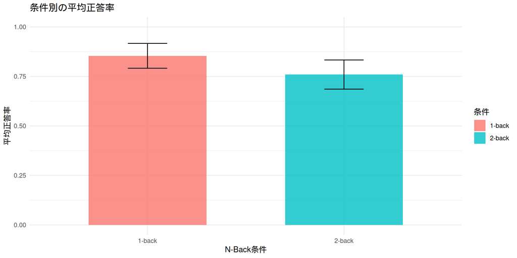

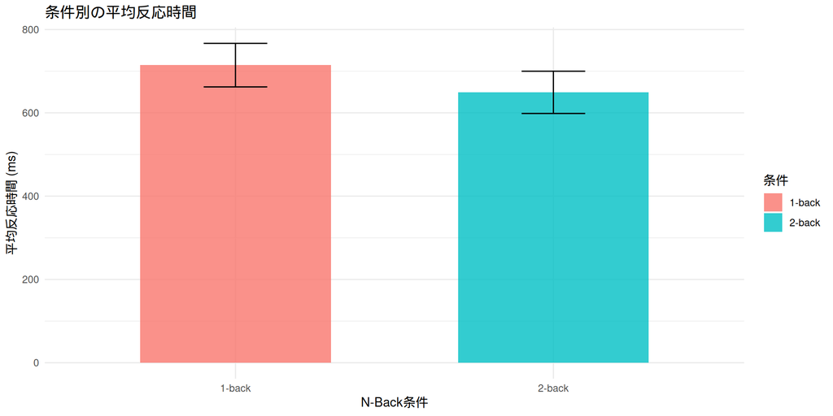

```
========== 1. 基礎統計量 (正答率 & 反応時間) ==========
```

[output not shown]

```
========== 2. 正答率の t検定結果 ==========
```

```
    Paired t-test

data:  wide_acc[[2]] and wide_acc[[3]]
t = 2.4598, df = 16, p-value = 0.02566
alternative hypothesis: true mean difference is not equal to 0
95 percent confidence interval:
 0.01305548 0.17591015
sample estimates:
mean difference
     0.09448281
```

```
========== 3. 反応時間(ms)の t検定結果 ==========
```

```
    Paired t-test

data:  wide_rt[[2]] and wide_rt[[3]]
t = 1.3047, df = 15, p-value = 0.2116
alternative hypothesis: true mean difference is not equal to 0
95 percent confidence interval:
 -41.39762 172.06888
sample estimates:
mean difference
       65.33563
```

## 4. 考察 (Discussion)

分析の結果、正答率に関する仮説は支持されたものの、反応時間に関する仮説は支持されなかった。 この理由として、正答率に関しては2-back条件によってワーキングメモリへの負荷が増加し、処理エラーも増加したのだと考えられる。反応時間に関しては、次の刺激までの回答時間が限られていることから、参加者が考えるよりも回答することを優先していた可能性が挙げられる。 また、本実験の限界としてサンプルサイズが比較的小さかったことと、実験環境に起因する入力の遅延まで完全には条件を揃えられなかった点が挙げられる。今後はサンプルサイズの拡大と実験環境の統制が求められる。

## 5. 引用文献 (References)

Baddeley, Alan. 2000. “The Episodic Buffer: A New Component of Working Memory?” *Trends in Cognitive Sciences* 4 (11): 417–23. https://doi.org/10.1016/s1364-6613(00)01538-2.